## Scenario

You want to clone a gene and you have some reporter for success of transformation in *E. coli*. Positive colonies are blue because they express $\beta$-galactosidase when plated on medium with IPTG. The probability of a successful transformation is $0 \le P(success) \le 1$. For the following exercise, you may consider one plate, many plates, or a truly gargantuan number of plates.

## Exercise

The class will split into 8 groups and each one will take one of the following distributions:

- Bernoulli
- Binomial
- Geometric
- Hypergeometric
- Negative binomial
- Poisson
- Normal
- Exponential

For your assigned distribution, answer the following questions. At the end of the class, each group will present their distribution and how it applies to the scenario above to the rest of the class.

#### a. What is your function? Describe it in terms of the kind of problem that it applies to. Is it discrete or continuous?

f(t)=lambda*e^(-lambda*t), where labda>0 and t>0 continuous describes the amount of time elapsed between events in a poisson point process memoryless

#### b. Describe a question that you can ask with your distribution as applied to the transformation scenario given above.

distance between transformed colonies to their closest transformed neighbor

#### c. Describe the parameterization of the equation. What parameters does it take, and what do they mean?

Takes lambda and t Lambda is the rate or density of transformed colonies, t is time or distance between colonies

#### d. Pick some appropriate parameters for your distribution as applied to the transformation scenario and graph the PDF and CDF.

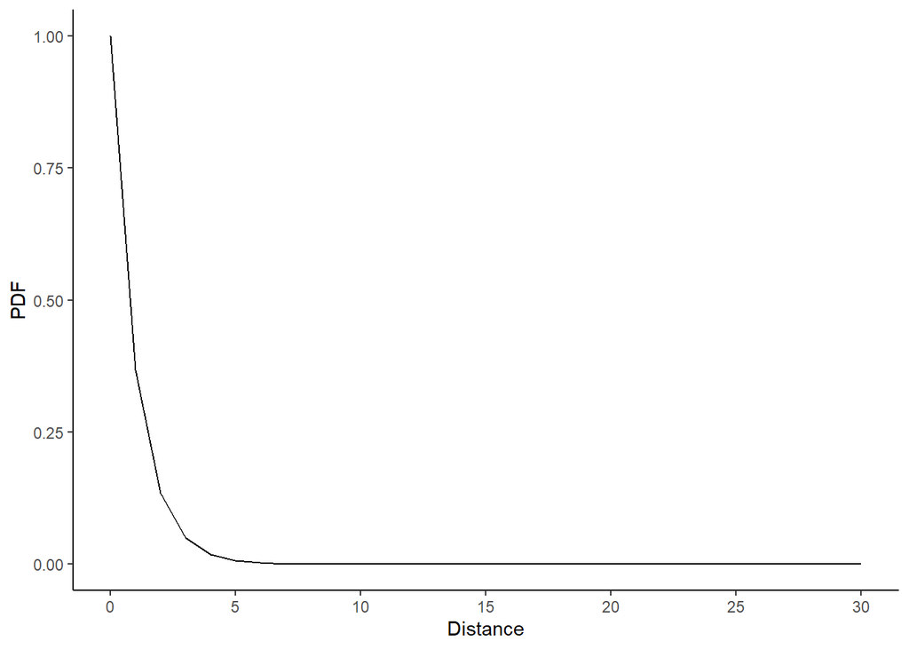

```r
lambda=1
colony.distance.pdf=dexp(0:30, lambda)
colony.distance.cdf=pexp(0:30, lambda)
colony.distance = data.frame(PDF = colony.distance.pdf, CDF=colony.distance.cdf, Distance=0:30)
ggplot( colony.distance ,aes( x = Distance ,y = PDF )) +
  theme_classic() +
  geom_line() +
  scale_x_continuous(breaks=pretty_breaks())
```

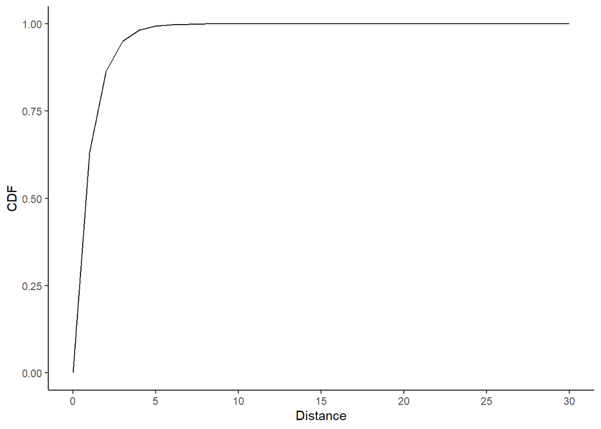

```r
ggplot( colony.distance ,aes( x = Distance ,y = CDF )) +
  theme_classic() +
  geom_line() +
  scale_x_continuous(breaks=pretty_breaks())
```

#### e. Compute a cumulative probability for some appropriate value and describe in words what it means. Be prepared to explain your answer to the class.

```r
colony.distance.cdf
```

```
##  [1] 0.0000000 0.6321206 0.8646647 0.9502129 0.9816844 0.9932621 0.9975212
##  [8] 0.9990881 0.9996645 0.9998766 0.9999546 0.9999833 0.9999939 0.9999977
## [15] 0.9999992 0.9999997 0.9999999 1.0000000 1.0000000 1.0000000 1.0000000
## [22] 1.0000000 1.0000000 1.0000000 1.0000000 1.0000000 1.0000000 1.0000000
## [29] 1.0000000 1.0000000 1.0000000
```

Given a density of one transformed colony per unit distance, here is a 100% chance of finding a transformed neighbor within 17 units of distance.

#### f. Identify at least one other distribution that yours relates to and be prepared to discuss the relationship between them. This could be a special case, a limiting case, an approximation, or an inverse CDF (survival) relationship.

continuous version of geometric distribution